# Cyclistic Trip Data Analysis

by Tasmiya Shirin

# *Scenario*

You are a junior data analyst working in the marketing analyst team at Cyclistic, a bike-share company in Chicago. The director of marketing believes the company’s future success depends on maximizing the number of annual memberships. Therefore, your team wants to understand how casual riders and annual members use Cyclistic bikes differently. From these insights, your team will design a new marketing strategy to convert casual riders into annual members. But first, Cyclistic executives must approve your recommendations, so they must be backed up with compelling data insights and professional data visualizations.

**Characters and teams**

> - Cyclistic: A bike-share program that features more than 5,800 bicycles and 600 docking stations. Cyclistic sets itself

apart by also offering reclining bikes, hand tricycles, and cargo bikes, making bike-share more inclusive to people with disabilities and riders who can’t use a standard two-wheeled bike. The majority of riders opt for traditional bikes; about 8% of riders use the assistive options. Cyclistic users are more likely to ride for leisure, but about 30% use them to commute to work each day.

> - Lily Moreno: The director of marketing and your manager. Moreno is responsible for the development of campaigns

and initiatives to promote the bike-share program. These may include email, social media, and other channels.

> - Cyclistic marketing analytics team: A team of data analysts who are responsible for collecting, analyzing, and

reporting data that helps guide Cyclistic marketing strategy. You joined this team six months ago and have been busy learning about Cyclistic’s mission and business goals — as well as how you, as a junior data analyst, can help Cyclistic achieve them.

> - Cyclistic executive team: The notoriously detail-oriented executive team will decide whether to approve the

recommended marketing program.

**About the company**

In 2016, Cyclistic launched a successful bike-share offering. Since then, the program has grown to a fleet of 5,824 bicycles that are geotracked and locked into a network of 692 stations across Chicago. The bikes can be unlocked from one station and returned to any other station in the system anytime. Until now, Cyclistic’s marketing strategy relied on building general awareness and appealing to broad consumer segments.

One approach that helped make these things possible was the flexibility of its pricing plans: single-ride passes, full-day passes, and annual memberships. Customers who purchase single-ride or full-day passes are referred to as casual riders. Customers who purchase annual memberships are Cyclistic members. Cyclistic’s finance analysts have concluded that annual members are much more profitable than casual riders. Although the pricing flexibility helps Cyclistic attract more customers, Moreno believes that maximizing the number of annual members will be key to future growth. Rather than creating a marketing campaign that targets all-new customers, Moreno believes there is a very good chance to convert casual riders into members. She notes that casual riders are already aware of the Cyclistic program and have chosen Cyclistic for their mobility needs.

Moreno has set a clear goal: Design marketing strategies aimed at converting casual riders into annual members. In order to do that, however, the marketing analyst team needs to better understand how annual members and casual riders differ, why casual riders would buy a membership, and how digital media could affect their marketing tactics. Moreno and her team are interested in analyzing the Cyclistic historical bike trip data to identify trends.

### **Ask**

Three questions will guide the future marketing program:

1. How do annual members and casual riders use Cyclistic bikes differently?
2. Why would casual riders buy Cyclistic annual memberships?
3. How can Cyclistic use digital media to influence casual riders to become members?

### **Prepare**

You will use Cyclistic’s historical trip data to analyze and identify trends. [Download the previous 12 months of Cyclistic trip data here.](https://divvy-tripdata.s3.amazonaws.com/index.html) ***(Note: The datasets have a different name because Cyclistic is a fictional company. For the purposes of this case study, the datasets are appropriate and will enable you to answer the business questions. The data has been made available by Motivate International Inc. under this license.)***

This is public data that you can use to explore how different customer types are using Cyclistic bikes. But note that data-privacy issues prohibit you from using riders’ personally identifiable information. This means that you won’t be able to connect pass purchases to credit card numbers to determine if casual riders live in the Cyclistic service area or if they have purchased multiple single passes.

#### **Guiding questions**

1. Where is your data located?

   -> The data is located in laptop's C drive.
2. How is the data organized?

   -> The data is separated by month, each on it's own csv.
3. Are there issues with bias or credibility in this data? Does your data ROCCC?

   -> Bias isn't a problem, the population of the dataset is it's own clients as bike riders. And have full credibility for the same reason. And finally, it's ROCCC because it's reliable, original, comprehensive, current and cited.
4. How are you addressing licensing, privacy, security, and accessibility?

   -> The company has their own licence over the dataset. Besides that, the dataset doesn't have any personal information about the riders.
5. How did you verify the data’s integrity?

   -> All the files have consistent columns and each column has the correct type of data.
6. How does it help you answer your question?

   -> It may have some key insights about the riders and their riding style
7. Are there any problems with the data?

   -> It would be good to have some updated information about the bike stations. Also more information about the riders could be useful.

### **Analyze**

Now that your data is stored appropriately and has been prepared for analysis, start putting it to work.

1. Import your data.
2. Make columns consistent and merge them into a single dataframe.
3. Clean up and add data to prepare for analysis.
4. Conduct descriptive analysis.
5. Export a summary file for further analysis.

# *Data Loading and Preprocessing*

```python
import pandas as pd
from pandas.api.types import CategoricalDtype

from scipy import stats

import numpy as np
import seaborn as sns
import matplotlib.pyplot as plt

import plotly.express as px
import plotly.graph_objects as go

%matplotlib inline
```

```python
April2020=pd.read_csv("C:/Users/Tashm/Datasets/Google_Capstone_Project/Cyclistic_Trip_Data/202004-divvy-tripdata/202004-divvy-tripdata.csv")
May2020=pd.read_csv("C:/Users/Tashm/Datasets/Google_Capstone_Project/Cyclistic_Trip_Data/202005-divvy-tripdata/202005-divvy-tripdata.csv")
June2020=pd.read_csv("C:/Users/Tashm/Datasets/Google_Capstone_Project/Cyclistic_Trip_Data/202006-divvy-tripdata/202006-divvy-tripdata.csv")
July2020=pd.read_csv("C:/Users/Tashm/Datasets/Google_Capstone_Project/Cyclistic_Trip_Data/202007-divvy-tripdata/202007-divvy-tripdata.csv")
Aug2020=pd.read_csv("C:/Users/Tashm/Datasets/Google_Capstone_Project/Cyclistic_Trip_Data/202008-divvy-tripdata/202008-divvy-tripdata.csv")
Sept2020=pd.read_csv("C:/Users/Tashm/Datasets/Google_Capstone_Project/Cyclistic_Trip_Data/202009-divvy-tripdata/202009-divvy-tripdata.csv")
Oct2020=pd.read_csv("C:/Users/Tashm/Datasets/Google_Capstone_Project/Cyclistic_Trip_Data/202010-divvy-tripdata/202010-divvy-tripdata.csv")
Nov2020=pd.read_csv("C:/Users/Tashm/Datasets/Google_Capstone_Project/Cyclistic_Trip_Data/202011-divvy-tripdata/202011-divvy-tripdata.csv")
Dec2020=pd.read_csv("C:/Users/Tashm/Datasets/Google_Capstone_Project/Cyclistic_Trip_Data/202012-divvy-tripdata/202012-divvy-tripdata.csv")
Jan2021=pd.read_csv("C:/Users/Tashm/Datasets/Google_Capstone_Project/Cyclistic_Trip_Data/202101-divvy-tripdata/202101-divvy-tripdata.csv")
Feb2021=pd.read_csv("C:/Users/Tashm/Datasets/Google_Capstone_Project/Cyclistic_Trip_Data/202102-divvy-tripdata/202102-divvy-tripdata.csv")
March2021=pd.read_csv("C:/Users/Tashm/Datasets/Google_Capstone_Project/Cyclistic_Trip_Data/202103-divvy-tripdata/202103-divvy-tripdata.csv")
April2021=pd.read_csv("C:/Users/Tashm/Datasets/Google_Capstone_Project/Cyclistic_Trip_Data/202104-divvy-tripdata/202104-divvy-tripdata.csv")
May2021=pd.read_csv("C:/Users/Tashm/Datasets/Google_Capstone_Project/Cyclistic_Trip_Data/202105-divvy-tripdata/202105-divvy-tripdata.csv")
June2021=pd.read_csv("C:/Users/Tashm/Datasets/Google_Capstone_Project/Cyclistic_Trip_Data/202106-divvy-tripdata/202106-divvy-tripdata.csv")
July2021=pd.read_csv("C:/Users/Tashm/Datasets/Google_Capstone_Project/Cyclistic_Trip_Data/202107-divvy-tripdata/202107-divvy-tripdata.csv")
Aug2021=pd.read_csv("C:/Users/Tashm/Datasets/Google_Capstone_Project/Cyclistic_Trip_Data/202108-divvy-tripdata/202108-divvy-tripdata.csv")
Sept2021=pd.read_csv("C:/Users/Tashm/Datasets/Google_Capstone_Project/Cyclistic_Trip_Data/202109-divvy-tripdata/202109-divvy-tripdata.csv")
Oct2021=pd.read_csv("C:/Users/Tashm/Datasets/Google_Capstone_Project/Cyclistic_Trip_Data/202110-divvy-tripdata/202110-divvy-tripdata.csv")
Nov2021=pd.read_csv("C:/Users/Tashm/Datasets/Google_Capstone_Project/Cyclistic_Trip_Data/202111-divvy-tripdata/202111-divvy-tripdata.csv")
Dec2021=pd.read_csv("C:/Users/Tashm/Datasets/Google_Capstone_Project/Cyclistic_Trip_Data/202112-divvy-tripdata/202112-divvy-tripdata.csv")
Jan2022=pd.read_csv("C:/Users/Tashm/Datasets/Google_Capstone_Project/Cyclistic_Trip_Data/202201-divvy-tripdata/202201-divvy-tripdata.csv")
Feb2022=pd.read_csv("C:/Users/Tashm/Datasets/Google_Capstone_Project/Cyclistic_Trip_Data/202202-divvy-tripdata/202202-divvy-tripdata.csv")
March2022=pd.read_csv("C:/Users/Tashm/Datasets/Google_Capstone_Project/Cyclistic_Trip_Data/202203-divvy-tripdata/202203-divvy-tripdata.csv")
April2022=pd.read_csv("C:/Users/Tashm/Datasets/Google_Capstone_Project/Cyclistic_Trip_Data/202204-divvy-tripdata/202204-divvy-tripdata.csv")
May2022=pd.read_csv("C:/Users/Tashm/Datasets/Google_Capstone_Project/Cyclistic_Trip_Data/202205-divvy-tripdata/202205-divvy-tripdata.csv")
June2022=pd.read_csv("C:/Users/Tashm/Datasets/Google_Capstone_Project/Cyclistic_Trip_Data/202206-divvy-tripdata/202206-divvy-tripdata.csv")
July2022=pd.read_csv("C:/Users/Tashm/Datasets/Google_Capstone_Project/Cyclistic_Trip_Data/202207-divvy-tripdata/202207-divvy-tripdata.csv")
Aug2022=pd.read_csv("C:/Users/Tashm/Datasets/Google_Capstone_Project/Cyclistic_Trip_Data/202208-divvy-tripdata/202208-divvy-tripdata.csv")
Sept2022=pd.read_csv("C:/Users/Tashm/Datasets/Google_Capstone_Project/Cyclistic_Trip_Data/202209-divvy-tripdata/202209-divvy-publictripdata.csv")
Oct2022=pd.read_csv("C:/Users/Tashm/Datasets/Google_Capstone_Project/Cyclistic_Trip_Data/202210-divvy-tripdata/202210-divvy-tripdata.csv")
Nov2022=pd.read_csv("C:/Users/Tashm/Datasets/Google_Capstone_Project/Cyclistic_Trip_Data/202211-divvy-tripdata/202211-divvy-tripdata.csv")
Dec2022=pd.read_csv("C:/Users/Tashm/Datasets/Google_Capstone_Project/Cyclistic_Trip_Data/202212-divvy-tripdata/202212-divvy-tripdata.csv")
Jan2023=pd.read_csv("C:/Users/Tashm/Datasets/Google_Capstone_Project/Cyclistic_Trip_Data/202301-divvy-tripdata/202301-divvy-tripdata.csv")
Feb2023=pd.read_csv("C:/Users/Tashm/Datasets/Google_Capstone_Project/Cyclistic_Trip_Data/202302-divvy-tripdata/202302-divvy-tripdata.csv")
March2023=pd.read_csv("C:/Users/Tashm/Datasets/Google_Capstone_Project/Cyclistic_Trip_Data/202303-divvy-tripdata/202303-divvy-tripdata.csv")
April2023=pd.read_csv("C:/Users/Tashm/Datasets/Google_Capstone_Project/Cyclistic_Trip_Data/202304-divvy-tripdata/202304-divvy-tripdata.csv")
May2023=pd.read_csv("C:/Users/Tashm/Datasets/Google_Capstone_Project/Cyclistic_Trip_Data/202305-divvy-tripdata/202305-divvy-tripdata.csv")
June2023=pd.read_csv("C:/Users/Tashm/Datasets/Google_Capstone_Project/Cyclistic_Trip_Data/202306-divvy-tripdata/202306-divvy-tripdata.csv")
July2023=pd.read_csv("C:/Users/Tashm/Datasets/Google_Capstone_Project/Cyclistic_Trip_Data/202307-divvy-tripdata/202307-divvy-tripdata.csv")
Aug2023=pd.read_csv("C:/Users/Tashm/Datasets/Google_Capstone_Project/Cyclistic_Trip_Data/202308-divvy-tripdata/202308-divvy-tripdata.csv")
Sept2023=pd.read_csv("C:/Users/Tashm/Datasets/Google_Capstone_Project/Cyclistic_Trip_Data/202309-divvy-tripdata/202309-divvy-tripdata.csv")
Oct2023=pd.read_csv("C:/Users/Tashm/Datasets/Google_Capstone_Project/Cyclistic_Trip_Data/202310-divvy-tripdata/202310-divvy-tripdata.csv")
```

```python
data=pd.concat([April2020, May2020, June2020, July2020, Aug2020, Sept2020, Oct2020, Nov2020, Dec2020, Jan2021, Feb2021, March2021, April2021, May2021, June2021, July2021, Aug2021, Sept2021, Oct2021, Nov2021, Dec2021, Jan2022, Feb2022, March2022, April2022, May2022, June2022, July2022, Aug2022, Sept2022, Oct2022, Nov2022, Dec2022, Jan2023, Feb2023, March2023, April2023, May2023, June2023, July2023, Aug2023, Sept2023, Oct2023], ignore_index=True)
```

```python
data.head()
```

|  | ride_id | rideable_type | started_at | ended_at | start_station_name | start_station_id | end_station_name | end_station_id | start_lat | start_lng | end_lat | end_lng | member_casual |
| --- | --- | --- | --- | --- | --- | --- | --- | --- | --- | --- | --- | --- | --- |
| 0 | A847FADBBC638E45 | docked_bike | 2020-04-26 17:45:14 | 2020-04-26 18:12:03 | Eckhart Park | 86 | Lincoln Ave & Diversey Pkwy | 152.0 | 41.8964 | -87.6610 | 41.9322 | -87.6586 | member |
| 1 | 5405B80E996FF60D | docked_bike | 2020-04-17 17:08:54 | 2020-04-17 17:17:03 | Drake Ave & Fullerton Ave | 503 | Kosciuszko Park | 499.0 | 41.9244 | -87.7154 | 41.9306 | -87.7238 | member |
| 2 | 5DD24A79A4E006F4 | docked_bike | 2020-04-01 17:54:13 | 2020-04-01 18:08:36 | McClurg Ct & Erie St | 142 | Indiana Ave & Roosevelt Rd | 255.0 | 41.8945 | -87.6179 | 41.8679 | -87.6230 | member |
| 3 | 2A59BBDF5CDBA725 | docked_bike | 2020-04-07 12:50:19 | 2020-04-07 13:02:31 | California Ave & Division St | 216 | Wood St & Augusta Blvd | 657.0 | 41.9030 | -87.6975 | 41.8992 | -87.6722 | member |
| 4 | 27AD306C119C6158 | docked_bike | 2020-04-18 10:22:59 | 2020-04-18 11:15:54 | Rush St & Hubbard St | 125 | Sheridan Rd & Lawrence Ave | 323.0 | 41.8902 | -87.6262 | 41.9695 | -87.6547 | casual |

```python
data.start_station_name.nunique()
```

```
2056
```

```python
data.end_station_name.nunique()
```

```
2067
```

```python
data.rideable_type.nunique()
```

```
3
```

```python
data.rideable_type.unique()
```

```
array(['docked_bike', 'electric_bike', 'classic_bike'], dtype=object)
```

```python
data.start_station_id.nunique()
```

```
2242
```

```python
data.end_station_id.nunique()
```

```
2244
```

```python
data.member_casual.nunique()
```

```
2
```

```python
data.member_casual.unique()
```

```
array(['member', 'casual'], dtype=object)
```

```python
data.info()
```

```
<class 'pandas.core.frame.DataFrame'>
RangeIndex: 19510862 entries, 0 to 19510861
Data columns (total 13 columns):
 #   Column              Dtype
---  ------              -----
 0   ride_id             object
 1   rideable_type       object
 2   started_at          object
 3   ended_at            object
 4   start_station_name  object
 5   start_station_id    object
 6   end_station_name    object
 7   end_station_id      object
 8   start_lat           float64
 9   start_lng           float64
 10  end_lat             float64
 11  end_lng             float64
 12  member_casual       object
dtypes: float64(4), object(9)
memory usage: 1.9+ GB
```

```python
data.duplicated().sum()
```

```
0
```

```python
data.isnull().sum()
```

```
ride_id                     0
rideable_type               0
started_at                  0
ended_at                    0
start_station_name    2403532
start_station_id      2404287
end_station_name      2576171
end_station_id        2576773
start_lat                   0
start_lng                   0
end_lat                 21284
end_lng                 21284
member_casual               0
dtype: int64
```

# *Data Wrangling*

```python
# Dropping the columns
data=data.drop(['start_station_name', 'end_station_name', 'start_station_id', 'end_station_id'], axis=1)
data.head()
```

|  | ride_id | rideable_type | started_at | ended_at | start_lat | start_lng | end_lat | end_lng | member_casual |
| --- | --- | --- | --- | --- | --- | --- | --- | --- | --- |
| 0 | A847FADBBC638E45 | docked_bike | 2020-04-26 17:45:14 | 2020-04-26 18:12:03 | 41.8964 | -87.6610 | 41.9322 | -87.6586 | member |
| 1 | 5405B80E996FF60D | docked_bike | 2020-04-17 17:08:54 | 2020-04-17 17:17:03 | 41.9244 | -87.7154 | 41.9306 | -87.7238 | member |
| 2 | 5DD24A79A4E006F4 | docked_bike | 2020-04-01 17:54:13 | 2020-04-01 18:08:36 | 41.8945 | -87.6179 | 41.8679 | -87.6230 | member |
| 3 | 2A59BBDF5CDBA725 | docked_bike | 2020-04-07 12:50:19 | 2020-04-07 13:02:31 | 41.9030 | -87.6975 | 41.8992 | -87.6722 | member |
| 4 | 27AD306C119C6158 | docked_bike | 2020-04-18 10:22:59 | 2020-04-18 11:15:54 | 41.8902 | -87.6262 | 41.9695 | -87.6547 | casual |

```python
# Convert 'started_at' and 'ended_at' column to datetime format
data['started_at'] = pd.to_datetime(data['started_at'])
data['ended_at'] = pd.to_datetime(data['ended_at'])
data[['started_at', 'ended_at']]
```

|  | started_at | ended_at |
| --- | --- | --- |
| 0 | 2020-04-26 17:45:14 | 2020-04-26 18:12:03 |
| 1 | 2020-04-17 17:08:54 | 2020-04-17 17:17:03 |
| 2 | 2020-04-01 17:54:13 | 2020-04-01 18:08:36 |
| 3 | 2020-04-07 12:50:19 | 2020-04-07 13:02:31 |
| 4 | 2020-04-18 10:22:59 | 2020-04-18 11:15:54 |
| ... | ... | ... |
| 19510857 | 2023-10-30 07:35:46 | 2023-10-30 07:49:30 |
| 19510858 | 2023-10-10 06:29:55 | 2023-10-10 06:45:19 |
| 19510859 | 2023-10-26 06:26:23 | 2023-10-26 06:39:43 |
| 19510860 | 2023-10-09 08:47:29 | 2023-10-09 08:47:33 |
| 19510861 | 2023-10-13 17:30:30 | 2023-10-13 17:42:15 |

19510862 rows × 2 columns

```python
# Calculate ride_length
data['ride_length'] = data['ended_at'] - data['started_at']
data['ride_length']
```

```
0          0 days 00:26:49
1          0 days 00:08:09
2          0 days 00:14:23
3          0 days 00:12:12
4          0 days 00:52:55
                 ...
19510857   0 days 00:13:44
19510858   0 days 00:15:24
19510859   0 days 00:13:20
19510860   0 days 00:00:04
19510861   0 days 00:11:45
Name: ride_length, Length: 19510862, dtype: timedelta64[ns]
```

```python
# Convert ride_length to string in HH:MM:SS format
data['ride_length'] = data['ride_length'].astype(str).str[-8:]
data['ride_length']
```

```
0           00:26:49
1           00:08:09
2           00:14:23
3           00:12:12
4           00:52:55
              ...
19510857    00:13:44
19510858    00:15:24
19510859    00:13:20
19510860    00:00:04
19510861    00:11:45
Name: ride_length, Length: 19510862, dtype: object
```

```python
# Calculating max ride length
max_r_l = data['ride_length'].max()
max_r_l
```

```
'23:59:59'
```

```python
# Converting ride_length in minutes
data['ride_length_minutes'] = pd.to_timedelta(data['ride_length']).dt.total_seconds() / 60
data['ride_length_minutes']
```

```
0           26.816667
1            8.150000
2           14.383333
3           12.200000
4           52.916667
              ...
19510857    13.733333
19510858    15.400000
19510859    13.333333
19510860     0.066667
19510861    11.750000
Name: ride_length_minutes, Length: 19510862, dtype: float64
```

```python
# Since ride_length_minutes dtype is float , convert it to int
data['ride_length_minutes'] = data['ride_length_minutes'].round().astype(int)
data['ride_length_minutes']
```

```
0           27
1            8
2           14
3           12
4           53
            ..
19510857    14
19510858    15
19510859    13
19510860     0
19510861    12
Name: ride_length_minutes, Length: 19510862, dtype: int32
```

```python
# Create the 'day_of_week' column containing day numbers
#data['day_of_week'] = data['started_at'].dt.dayofweek

# Calculate the day of the week (1=Sunday, 7=Saturday) and store it in 'day_of_week' column
data['day_of_week'] = data['started_at'].dt.dayofweek + 1

# Displaying 'day_of_week' column
data['day_of_week']
```

```
0           7
1           5
2           3
3           2
4           6
           ..
19510857    1
19510858    2
19510859    4
19510860    1
19510861    5
Name: day_of_week, Length: 19510862, dtype: int32
```

```python
# Create new columns for year, month, day and hour.
data['start_year'] = data['started_at'].dt.year
data['start_month'] = data['started_at'].dt.month_name()
data['start_day'] = data['started_at'].dt.day_name()
data['start_hour'] = data['started_at'].dt.hour

# Display the DataFrame with new columns for year, month, day and hour.
data[['start_year', 'start_month', 'start_day','start_hour']]
```

|  | start_year | start_month | start_day | start_hour |
| --- | --- | --- | --- | --- |
| 0 | 2020 | April | Sunday | 17 |
| 1 | 2020 | April | Friday | 17 |
| 2 | 2020 | April | Wednesday | 17 |
| 3 | 2020 | April | Tuesday | 12 |
| 4 | 2020 | April | Saturday | 10 |
| ... | ... | ... | ... | ... |
| 19510857 | 2023 | October | Monday | 7 |
| 19510858 | 2023 | October | Tuesday | 6 |
| 19510859 | 2023 | October | Thursday | 6 |
| 19510860 | 2023 | October | Monday | 8 |
| 19510861 | 2023 | October | Friday | 17 |

19510862 rows × 4 columns

```python
# Define the order of day in a list
day_order = ['Monday', 'Tuesday', 'Wednesday', 'Thursday', 'Friday', 'Saturday', 'Sunday']

# Convert 'start_day' to categorical with specified order
data['start_day'] = pd.Categorical(data['start_day'], categories=day_order, ordered=True)
```

```python
# Define the order of months in a list
month_order = ['January', 'February', 'March', 'April', 'May', 'June', 'July', 'August', 'September', 'October', 'November', 'December']

# Convert 'start_month' to a categorical variable with specified order
data['start_month'] = pd.Categorical(data['start_month'], categories=month_order, ordered=True)
```

```python
data.shape  #Returns a tuple representing the number of rows and columns in the dataset.
```

```
(19510862, 16)
```

```python
data.info()
```

```
<class 'pandas.core.frame.DataFrame'>
RangeIndex: 19510862 entries, 0 to 19510861
Data columns (total 16 columns):
 #   Column               Dtype
---  ------               -----
 0   ride_id              object
 1   rideable_type        object
 2   started_at           datetime64[ns]
 3   ended_at             datetime64[ns]
 4   start_lat            float64
 5   start_lng            float64
 6   end_lat              float64
 7   end_lng              float64
 8   member_casual        object
 9   ride_length          object
 10  ride_length_minutes  int32
 11  day_of_week          int32
 12  start_year           int32
 13  start_month          category
 14  start_day            category
 15  start_hour           int32
dtypes: category(2), datetime64[ns](2), float64(4), int32(4), object(4)
memory usage: 1.8+ GB
```

```python
data.describe() # Generate descriptive statistics of the numerical columns
```

|  | started_at | ended_at | start_lat | start_lng | end_lat | end_lng | ride_length_minutes | day_of_week | start_year | start_hour |
| --- | --- | --- | --- | --- | --- | --- | --- | --- | --- | --- |
| count | 19510862 | 19510862 | 1.951086e+07 | 1.951086e+07 | 1.948958e+07 | 1.948958e+07 | 1.951086e+07 | 1.951086e+07 | 1.951086e+07 | 1.951086e+07 |
| mean | 2022-03-19 17:24:24.880727296 | 2022-03-19 17:45:17.846426368 | 4.190253e+01 | -8.764663e+01 | 4.190279e+01 | -8.764681e+01 | 1.934100e+01 | 4.121997e+00 | 2.021657e+03 | 1.422994e+01 |
| min | 2020-04-01 00:00:30 | 2020-04-01 00:10:45 | 4.163000e+01 | -8.794000e+01 | 0.000000e+00 | -8.897000e+01 | 0.000000e+00 | 1.000000e+00 | 2.020000e+03 | 0.000000e+00 |
| 25% | 2021-06-20 12:56:41.249999872 | 2021-06-20 13:26:45 | 4.188132e+01 | -8.766013e+01 | 4.188164e+01 | -8.766028e+01 | 6.000000e+00 | 2.000000e+00 | 2.021000e+03 | 1.100000e+01 |
| 50% | 2022-05-11 18:41:13 | 2022-05-11 19:01:50.500000 | 4.189994e+01 | -8.764326e+01 | 4.190000e+01 | -8.764350e+01 | 1.100000e+01 | 4.000000e+00 | 2.022000e+03 | 1.500000e+01 |
| 75% | 2023-02-11 15:26:02 | 2023-02-11 15:42:36.750000128 | 4.193000e+01 | -8.762932e+01 | 4.193000e+01 | -8.762932e+01 | 2.000000e+01 | 6.000000e+00 | 2.023000e+03 | 1.800000e+01 |
| max | 2023-10-31 23:59:57 | 2023-11-01 21:23:59 | 4.563503e+01 | -7.379648e+01 | 4.237000e+01 | 0.000000e+00 | 1.440000e+03 | 7.000000e+00 | 2.023000e+03 | 2.300000e+01 |
| std | NaN | NaN | 4.543275e-02 | 2.830310e-02 | 5.536977e-02 | 7.166061e-02 | 5.025072e+01 | 1.978935e+00 | 1.034806e+00 | 4.949797e+00 |

```python
# Coverting datatypes of columns.
data = data.astype({'ride_id':'string', 'rideable_type':'category', 'member_casual':'category'})

data.info()
```

```
<class 'pandas.core.frame.DataFrame'>
RangeIndex: 19510862 entries, 0 to 19510861
Data columns (total 16 columns):
 #   Column               Dtype
---  ------               -----
 0   ride_id              string
 1   rideable_type        category
 2   started_at           datetime64[ns]
 3   ended_at             datetime64[ns]
 4   start_lat            float64
 5   start_lng            float64
 6   end_lat              float64
 7   end_lng              float64
 8   member_casual        category
 9   ride_length          object
 10  ride_length_minutes  int32
 11  day_of_week          int32
 12  start_year           int32
 13  start_month          category
 14  start_day            category
 15  start_hour           int32
dtypes: category(4), datetime64[ns](2), float64(4), int32(4), object(1), string(1)
memory usage: 1.5+ GB
```

```python
#Sorting the data based on the values in the column named 'ride_length_minutes' in ascending order.
data.sort_values(by='ride_length_minutes', inplace=True)   # The inplace=True parameter ensures that the changes are applied to the DataFrame itself, modifying it rather than just returning a sorted copy.
data.head()
```

|  | ride_id | rideable_type | started_at | ended_at | start_lat | start_lng | end_lat | end_lng | member_casual | ride_length | ride_length_minutes | day_of_week | start_year | start_month | start_day | start_hour |
| --- | --- | --- | --- | --- | --- | --- | --- | --- | --- | --- | --- | --- | --- | --- | --- | --- |
| 1197616 | DD01CCE3A4EBEABF | electric_bike | 2020-08-20 15:55:29 | 2020-08-20 15:55:34 | 41.894760 | -87.730880 | 41.894753 | -87.730883 | casual | 00:00:05 | 0 | 4 | 2020 | August | Thursday | 15 |
| 923220 | B9B136E6FA28E8B2 | docked_bike | 2020-07-16 22:04:36 | 2020-07-16 22:04:52 | 41.929465 | -87.684158 | 41.929465 | -87.684158 | member | 00:00:16 | 0 | 4 | 2020 | July | Thursday | 22 |
| 4323846 | 9F29E6B5882FD559 | electric_bike | 2021-05-29 00:10:08 | 2021-05-29 00:10:25 | 41.930000 | -87.700000 | 41.930000 | -87.700000 | member | 00:00:17 | 0 | 6 | 2021 | May | Saturday | 0 |
| 4323847 | C421B5311D78A7BD | electric_bike | 2021-05-16 19:37:44 | 2021-05-16 19:38:05 | 41.970000 | -87.640000 | 41.970000 | -87.640000 | member | 00:00:21 | 0 | 7 | 2021 | May | Sunday | 19 |
| 15595013 | 630AADC9DA6860F6 | classic_bike | 2023-05-16 18:46:57 | 2023-05-16 18:47:19 | 41.857412 | -87.613792 | 41.857412 | -87.613792 | member | 00:00:22 | 0 | 2 | 2023 | May | Tuesday | 18 |

```python
# Count of rows in the DataFrame data where the 'ride_length_minutes' column has negative values, indicating rides with a negative duration.
data[data['ride_length_minutes'] < 0].count()
```

```
ride_id                0
rideable_type          0
started_at             0
ended_at               0
start_lat              0
start_lng              0
end_lat                0
end_lng                0
member_casual          0
ride_length            0
ride_length_minutes    0
day_of_week            0
start_year             0
start_month            0
start_day              0
start_hour             0
dtype: int64
```

```python
# Count of rows in the DataFrame data where the 'ride_length_minutes' column has values less than 1 minute.
data[data['ride_length_minutes'] < 1].count()
```

```
ride_id                256855
rideable_type          256855
started_at             256855
ended_at               256855
start_lat              256855
start_lng              256855
end_lat                256755
end_lng                256755
member_casual          256855
ride_length            256855
ride_length_minutes    256855
day_of_week            256855
start_year             256855
start_month            256855
start_day              256855
start_hour             256855
dtype: int64
```

There are 256,855 rows in the dataset where the ride duration is less than 1 minute.

Any trips that were below 1 minute in length are potentially false starts or users trying to re-dock a bike to ensure it was secure.

```python
#  Filter out rows where the 'ride_length_minutes' column is less than 1 minute
data = data[data['ride_length_minutes'] >= 1]

# Resets the index of the DataFrame.
data = data.reset_index()

# Drops the 'index' column that was created during the reset_index operation. It removes the redundant 'index' column from the DataFrame.
data = data.drop(columns=['index'])

# Count the number of rows where the 'ride_length_minutes' column is less than 1 minute after the filtering operation.
data[data['ride_length_minutes'] < 1].count()
```

```
ride_id                0
rideable_type          0
started_at             0
ended_at               0
start_lat              0
start_lng              0
end_lat                0
end_lng                0
member_casual          0
ride_length            0
ride_length_minutes    0
day_of_week            0
start_year             0
start_month            0
start_day              0
start_hour             0
dtype: int64
```

```python
data.shape
```

```
(19254007, 16)
```

# *Descriptive Statistics Analysis and Outlier Removal*

```python
# Descriptive statistics of 'ride_length_minutes'
data['ride_length_minutes'].describe()
```

```
count    1.925401e+07
mean     1.959902e+01
std      5.053478e+01
min      1.000000e+00
25%      6.000000e+00
50%      1.100000e+01
75%      2.100000e+01
max      1.440000e+03
Name: ride_length_minutes, dtype: float64
```

```python
# Calculate Z-score for 'ride_length_minutes'
data['z_score'] = stats.zscore(data['ride_length_minutes'])

# Define a threshold for outlier detection (e.g., Z-score > 3 or < -3)
outliers = data[(data['z_score'] > 3) | (data['z_score'] < -3)]

# Display the outliers
#print(outliers)

#Display the outliers count
outlier_count = len(outliers)
outlier_count
```

```
97894
```

```python
# Remove outliers from the dataset
data_without_outliers = data[(data['z_score'] <= 3) & (data['z_score'] >= -3)]
data_without_outliers.head()
```

|  | ride_id | rideable_type | started_at | ended_at | start_lat | start_lng | end_lat | end_lng | member_casual | ride_length | ride_length_minutes | day_of_week | start_year | start_month | start_day | start_hour | z_score |
| --- | --- | --- | --- | --- | --- | --- | --- | --- | --- | --- | --- | --- | --- | --- | --- | --- | --- |
| 0 | 04CA390C2381F76B | electric_bike | 2023-05-28 10:58:56 | 2023-05-28 11:00:02 | 41.954153 | -87.654404 | 41.954245 | -87.654406 | casual | 00:01:06 | 1 | 7 | 2023 | May | Sunday | 10 | -0.368044 |
| 1 | 1F366FB131FEBD79 | electric_bike | 2021-01-18 18:06:56 | 2021-01-18 18:07:54 | 41.894861 | -87.634294 | 41.894754 | -87.634350 | member | 00:00:58 | 1 | 1 | 2021 | January | Monday | 18 | -0.368044 |
| 2 | 03255D618761C60A | classic_bike | 2022-08-18 13:32:47 | 2022-08-18 13:34:14 | 41.872078 | -87.629544 | 41.870816 | -87.631246 | casual | 00:01:27 | 1 | 4 | 2022 | August | Thursday | 13 | -0.368044 |
| 3 | 36F9D539029E364F | electric_bike | 2023-10-15 18:15:08 | 2023-10-15 18:16:37 | 41.920000 | -87.650000 | 41.920000 | -87.650000 | member | 00:01:29 | 1 | 7 | 2023 | October | Sunday | 18 | -0.368044 |
| 4 | D68B9FCB56238955 | classic_bike | 2022-04-26 11:45:49 | 2022-04-26 11:46:52 | 41.872950 | -87.669130 | 41.871514 | -87.669886 | member | 00:01:03 | 1 | 2 | 2022 | April | Tuesday | 11 | -0.368044 |

```python
data_without_outliers.shape
```

```
(19156113, 17)
```

**Using `data_without_outliers` DataFrame for descriptive statistics analysis**

```python
#  Performs aggregation operations on a DataFrame named 'data_without_outliers', grouping the data by the 'member_casual' column.

grouped_ride_time = data_without_outliers.groupby('member_casual', observed=False).agg(
    mean=('ride_length_minutes', 'mean'),  # Calculating the mean ride length within each group
    first_quarter=('ride_length_minutes', lambda x: np.percentile(x, 25)),  # Computing the 25th percentile (first quartile)
    median=('ride_length_minutes', 'median'),  # Calculating the median ride length within each group
    third_quarter=('ride_length_minutes', lambda x: np.percentile(x, 75)),  # Computing the 75th percentile (third quartile)
    IR=('ride_length_minutes', lambda x: np.percentile(x, 75) - np.percentile(x, 25))  # Calculating the interquartile range  (difference between the 75th and 25th percentiles) of 'ride_length_minutes' within each group using lambda functions and np.percentile.
)

grouped_ride_time
```

| member_casual | mean | first_quarter | median | third_quarter | IR |
| --- | --- | --- | --- | --- | --- |
| casual | 23.102148 | 8.0 | 15.0 | 28.0 | 20.0 |
| member | 12.864046 | 6.0 | 10.0 | 16.0 | 10.0 |

The mean ride length for **casual riders is notably longer than for member riders.** Additionally, the quartile values (25th, 50th, and 75th percentiles) help understand the spread and variation of ride durations within each group. The Interquartile Range (IQR) represents the spread of the middle 50% of the data, showing how much variation exists in the central part of the distribution.

1. *A box plot visualizing ride length statistics (mean, quartiles, and median) for both member and casual riders, allowing for a comparison of ride duration distributions between these two groups.*

```python
# Resetting index to access 'member_casual' as a column for Plotly Express
grouped_ride_time_reset = grouped_ride_time.reset_index()

# Creating a box plot using Plotly Express
fig = px.box(grouped_ride_time_reset, x='member_casual', y=['mean', 'first_quarter', 'median', 'third_quarter'],
             labels={'member_casual': 'Member Type', 'variable': 'Statistic', 'value': 'Ride Length'},
             template='plotly_white',
             color='member_casual',  # Assigning colors based on member_casual column
             color_discrete_map={'member': 'purple', 'casual': 'green'}  # Customizing colors
             )

fig.update_traces(boxmean=True)  # Display mean as a line inside the box

# Update layout to set title in the center
fig.update_layout(width=1400, title=dict(text='Ride Length Without Outliers Statistics by Member Type', x=0.5))

fig.show()
```

[output not shown]

2. *A box plot that illustrates the distribution of riding time for different member types, helping to compare the riding time distributions between members and casual riders.*

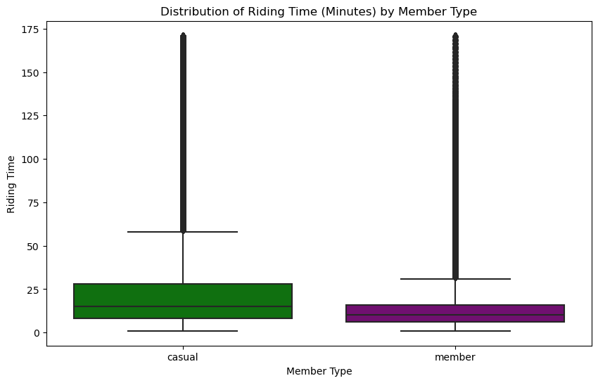

```python
# Create a box plot using Plotly Express with color customization
        #fig = px.box(data_without_outliers, x='member_casual', y='ride_length_minutes',
        #             title='Distribution of Riding Time (Minutes) by Member Type',
        #             labels={'member_casual': 'Member Type', 'ride_length_minutes': 'Riding Time'},
        #             template='plotly_white',
        #             color='member_casual',  # Assigning colors based on member_casual column
        #             color_discrete_map={'member': 'purple', 'casual': 'green'}  # Customizing colors
        #             )

        #fig.update_traces(boxmean=True)  # Display mean as a line inside the box

        #fig.show()

# Create a box plot using Seaborn
plt.figure(figsize=(10, 6))  # Adjust the figure size if needed
sns.boxplot(data=data_without_outliers, x='member_casual', y='ride_length_minutes',
            palette={'member': 'purple', 'casual': 'green'})

# Adding title and labels
plt.title('Distribution of Riding Time (Minutes) by Member Type')
plt.xlabel('Member Type')
plt.ylabel('Riding Time')

plt.show()
```

3. *A box plot depicting the distribution of riding time (in minutes) categorized by different rideable types (docked bike, electric bike, classic bike) while distinguishing between member and casual riders.*

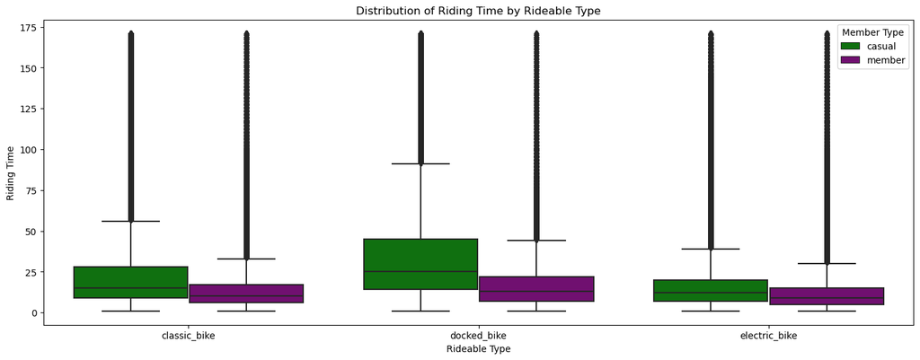

```python
# Creating a box plot using Plotly Express with filtered data
#fig = px.box(data_without_outliers, x='rideable_type', y='ride_length_minutes',
#             title='Distribution of Riding Time by Rideable Type',
#             labels={'rideable_type': 'Rideable Type', 'ride_length_minutes': 'Riding Time'},
#             template='plotly_white',
#            color='member_casual',  # Assigning colors based on member_casual column
#             color_discrete_map={'member': 'purple', 'casual': 'green'}  # Customizing colors
#             )

#fig.update_traces(boxmean=True)  # Display mean as a line inside the box

#fig.show()

# Creating a box plot using Seaborn
plt.figure(figsize=(17, 6))  # Adjust the figure size if needed
sns.boxplot(data=data_without_outliers, x='rideable_type', y='ride_length_minutes', hue='member_casual',
            palette={'member': 'purple', 'casual': 'green'})

# Adding title and labels
plt.title('Distribution of Riding Time by Rideable Type')
plt.xlabel('Rideable Type')
plt.ylabel('Riding Time')
plt.legend(title='Member Type')

plt.show()
```

## *Further Analysis and Data Processing*

> *We will perform the comparison between statistics derived from the data DataFrame which contains original data and the data_without_outliers DataFrame.*

This will provide insights into how outliers impact various statistical measures. By analyzing both datasets, we can observe how the presence or absence of outliers affects central tendency, dispersion, and other statistical characteristics of the ride lengths.

1. *Comparing Mean of ride length*

```python
# Calculating mean ride length
mean_ride_length = data['ride_length_minutes'].mean()
mean_ride_length
```

```
19.599018791257322
```

```python
# Calculating mean ride length wihtout outliers
mean_ride_length_without_outliers = data_without_outliers['ride_length_minutes'].mean()
mean_ride_length_without_outliers
```

```
17.089490440988733
```

This indicates that the removal of outliers has led to a decrease in the average ride length from 19.599 minutes (when outliers were included) to 17.089 minutes (when outliers were excluded). The difference between these two mean values suggests that outliers were contributing to a higher average ride length in the original dataset.

2. *Comparing Maximum ride length*

```python
# Calculating max ride length
max_ride_length = data['ride_length_minutes'].max()
max_ride_length
```

```
1440
```

```python
# Calculating max ride length wihtout outliers
max_ride_length_without_outliers = data_without_outliers['ride_length_minutes'].max()
max_ride_length_without_outliers
```

```
171
```

This substantial decrease in the maximum ride length from 1440 minutes (when outliers were included) to 171 minutes (when outliers were excluded) further emphasizes the significant impact outliers have on extreme values within the dataset.

Removing outliers has resulted in a considerable reduction in the maximum ride length, indicating that outliers were driving the maximum value to an unusually high extent in the original dataset.

3. *Calculating Mode of day_of_week*

```python
# Calculating mode (most frequent value)  of day_of_week
mode_day_of_week = data['day_of_week'].mode().values[0]   #  .values[0] extracts the first (or the only) value from the resulting mode series.
mode_day_of_week
```

```
6
```

4. *Comparing count of ride length which is less than 60 minutes (1 Hour)*

```python
# Filtering data where ride length is less than 60
data_time_low = data[data['ride_length_minutes'] < 60]

# Counting non-null entries in 'data_time_low'
data_time_low.count()
```

```
ride_id                18456597
rideable_type          18456597
started_at             18456597
ended_at               18456597
start_lat              18456597
start_lng              18456597
end_lat                18453183
end_lng                18453183
member_casual          18456597
ride_length            18456597
ride_length_minutes    18456597
day_of_week            18456597
start_year             18456597
start_month            18456597
start_day              18456597
start_hour             18456597
z_score                18456597
dtype: int64
```

```python
# Filtering data without outliers where ride length is smaller than 60
data_outliers_time_low = data_without_outliers[data_without_outliers['ride_length_minutes'] < 60]

# Counting non-null entries in 'data_outliers_time_low'
data_outliers_time_low.count()
```

```
ride_id                18456597
rideable_type          18456597
started_at             18456597
ended_at               18456597
start_lat              18456597
start_lng              18456597
end_lat                18453183
end_lng                18453183
member_casual          18456597
ride_length            18456597
ride_length_minutes    18456597
day_of_week            18456597
start_year             18456597
start_month            18456597
start_day              18456597
start_hour             18456597
z_score                18456597
dtype: int64
```

5. *Comparing count of ride length which is greater than 60 minutes (1 Hour)*

```python
# Filtering data where ride length is greater than 60
data_time_high = data[data['ride_length_minutes'] > 60]

# Counting non-null entries in 'data_time_high'
data_time_high.count()
```

```
ride_id                763228
rideable_type          763228
started_at             763228
ended_at               763228
start_lat              763228
start_lng              763228
end_lat                756729
end_lng                756729
member_casual          763228
ride_length            763228
ride_length_minutes    763228
day_of_week            763228
start_year             763228
start_month            763228
start_day              763228
start_hour             763228
z_score                763228
dtype: int64
```

```python
# Filtering data where ride length is greater than 60
data_outliers_time_high = data_without_outliers[data_without_outliers['ride_length_minutes'] > 60]

# Counting non-null entries in 'data_time_high'
data_outliers_time_high.count()
```

```
ride_id                665334
rideable_type          665334
started_at             665334
ended_at               665334
start_lat              665334
start_lng              665334
end_lat                663798
end_lng                663798
member_casual          665334
ride_length            665334
ride_length_minutes    665334
day_of_week            665334
start_year             665334
start_month            665334
start_day              665334
start_hour             665334
z_score                665334
dtype: int64
```

6. *Caculating the count of ride length which we have removed as outliers in data_without_outliers.*

```python
data_above_171 = data[(data['ride_length_minutes']>171) & (data['ride_length_minutes'] < 1440) ]
data_above_171.count()
```

```
ride_id                89052
rideable_type          89052
started_at             89052
ended_at               89052
start_lat              89052
start_lng              89052
end_lat                84126
end_lng                84126
member_casual          89052
ride_length            89052
ride_length_minutes    89052
day_of_week            89052
start_year             89052
start_month            89052
start_day              89052
start_hour             89052
z_score                89052
dtype: int64
```

7. *Comparing Mean ride length between member and casual*

```python
# Grouping data by 'start_day' and 'member_casual' and calculating mean ride length
Grouped_mean =data.groupby(['start_day', 'member_casual'], observed=False)['ride_length_minutes'].mean()
Grouped_mean
```

```
start_day  member_casual
Monday     casual           26.869374
           member           13.494704
Tuesday    casual           24.296173
           member           13.514600
Wednesday  casual           23.373494
           member           13.534601
Thursday   casual           23.659056
           member           13.442846
Friday     casual           25.819378
           member           14.337810
Saturday   casual           30.143543
           member           16.061562
Sunday     casual           31.283347
           member           16.094409
Name: ride_length_minutes, dtype: float64
```

```python
# Grouping data without outliers by 'start_day' and 'member_casual' and calculating mean ride length
Grouped_outliers_data_mean =data_without_outliers.groupby(['start_day', 'member_casual'], observed=False)['ride_length_minutes'].mean()
Grouped_outliers_data_mean
```

```
start_day  member_casual
Monday     casual           23.037749
           member           12.314000
Tuesday    casual           20.765075
           member           12.178164
Wednesday  casual           20.147039
           member           12.229657
Thursday   casual           20.269420
           member           12.276650
Friday     casual           21.817600
           member           12.654899
Saturday   casual           25.631822
           member           14.388502
Sunday     casual           26.560308
           member           14.449206
Name: ride_length_minutes, dtype: float64
```

It won't be a problem if we continue with our data with outliers.

```python
# Dropping rows with NaN/null values
data = data.dropna()
```

```python
# Checking for null values after dropping rows
data.isnull().sum()
```

```
ride_id                0
rideable_type          0
started_at             0
ended_at               0
start_lat              0
start_lng              0
end_lat                0
end_lng                0
member_casual          0
ride_length            0
ride_length_minutes    0
day_of_week            0
start_year             0
start_month            0
start_day              0
start_hour             0
z_score                0
dtype: int64
```

```python
data.shape
```

```
(19232823, 17)
```

```python
data.columns
```

```
Index(['ride_id', 'rideable_type', 'started_at', 'ended_at', 'start_lat',
       'start_lng', 'end_lat', 'end_lng', 'member_casual', 'ride_length',
       'ride_length_minutes', 'day_of_week', 'start_year', 'start_month',
       'start_day', 'start_hour', 'z_score'],
      dtype='object')
```

# *Exploratory Data Analysis (EDA)*

### *Rides Count Analysis*

#### *1. Ride Count by User Type*

```python
#data.Member_Status.value_counts()

# Group by 'member_casual' and calculate counts and percentages
grouped_member_casual = data.groupby('member_casual', observed=False ).agg(
    count=('ride_id', 'size'),
    percentage=('ride_id', lambda x: (len(x) / len(data)) * 100)
).reset_index()
grouped_member_casual
```

|  | member_casual | count | percentage |
| --- | --- | --- | --- |
| 0 | casual | 7966130 | 41.419453 |
| 1 | member | 11266693 | 58.580547 |

```python
# Define a custom color map for member_casual categories
color_map = {'member': 'purple', 'casual': 'green'}  # Replace with your desired colors

# Create a bar chart with custom colors using Plotly Express
fig = px.bar(grouped_member_casual, x='member_casual', y='count',
             labels={'member_casual': 'User Type', 'count': 'Ride Count'},
             title='Ride Counts by User Type',
             color='member_casual', color_discrete_map=color_map)

# Add data labels using update_traces()
fig.update_traces(texttemplate='%{y:.2f}', textposition='outside')

fig.update_layout(xaxis_title='User Type', yaxis_title='Ride Count',
                  width=800, height=500,
                  title=dict(text='Ride Counts by User Type', x=0.5))  # Set title alignment to center (x=0.5)

fig.show()
```

The 'member' category constitutes a larger portion of the data compared to the 'casual' category.

#### *2. Rides Count per Year by User Type*

```python
# Group by 'start_month' and calculate counts, percentages, and differences
rides_per_year = data.groupby('start_year', observed=False).agg(
    Total_count=('ride_id', 'size'),
    member_count=('member_casual', lambda x: sum(x == "member")),  # Count of 'member' per month
    casual_count=('member_casual', lambda x: sum(x == "casual")),   # Count of 'casual' per month
    percent=('ride_id', lambda x: (len(x) / len(data)) * 100),
    members_p=('member_casual', lambda x: (sum(x == "member") / len(x)) * 100),
    casual_p=('member_casual', lambda x: (sum(x == "casual") / len(x)) * 100)
)

# Calculate the difference between member and casual percentages
rides_per_year['Member x Casual Perc Difer'] = rides_per_year['members_p'] - rides_per_year['casual_p']

rides_per_year
```

| start_year | Total_count | member_count | casual_count | percent | members_p | casual_p | Member x Casual Perc Difer |
| --- | --- | --- | --- | --- | --- | --- | --- |
| 2020 | 3078983 | 1773820 | 1305163 | 16.009002 | 57.610581 | 42.389419 | 15.221162 |
| 2021 | 5534255 | 3031029 | 2503226 | 28.775053 | 54.768510 | 45.231490 | 9.537020 |
| 2022 | 5583051 | 3297245 | 2285806 | 29.028765 | 59.058121 | 40.941879 | 18.116241 |
| 2023 | 5036534 | 3164599 | 1871935 | 26.187180 | 62.832873 | 37.167127 | 25.665746 |

```python
# Reset index to access 'start_year' as a column
rides_per_year.reset_index(inplace=True)

# Create a bar chart using Plotly Express
fig = px.bar(rides_per_year, x='start_year', y=['member_count', 'casual_count'],
             labels={'start_year': 'Year', 'value': 'Count', 'variable': 'Count Type'},
             title='Rides Count per Year by User Type',
             barmode='group',
             color_discrete_map={'casual_count': 'green', 'member_count': 'purple'})

# Add data labels using update_traces()
fig.update_traces(texttemplate='%{y:.2f}', textposition='outside')

fig.update_layout(xaxis_title='Year', yaxis_title='Ride Count',
                  height=500, width=1400,
                  title=dict(text='Rides Count per Year by User Type', x=0.5))  # Set title alignment to center (x=0.5)

# Show the chart
fig.show()
```

The analysis indicates a positive trend in increasing membership and a growing proportion of rides from 'members', which can be valuable for devising marketing strategies to enhance membership conversion and retention among 'casual' riders.

#### *3. Rides Count per Month by User Type*

```python
# Group by 'start_month' and calculate counts, percentages, and differences
rides_per_month = data.groupby('start_month', observed=False).agg(
    Total_count=('ride_id', 'size'),
    member_count=('member_casual', lambda x: sum(x == "member")),  # Count of 'member' per month
    casual_count=('member_casual', lambda x: sum(x == "casual")),   # Count of 'casual' per month
    percent=('ride_id', lambda x: (len(x) / len(data)) * 100),
    members_p=('member_casual', lambda x: (sum(x == "member") / len(x)) * 100),
    casual_p=('member_casual', lambda x: (sum(x == "casual") / len(x)) * 100)
)

# Calculate the difference between member and casual percentages
rides_per_month['Member x Casual Perc Difer'] = rides_per_month['members_p'] - rides_per_month['casual_p']

rides_per_month
```

| start_month | Total_count | member_count | casual_count | percent | members_p | casual_p | Member x Casual Perc Difer |
| --- | --- | --- | --- | --- | --- | --- | --- |
| January | 384130 | 308897 | 75233 | 1.997263 | 80.414703 | 19.585297 | 60.829407 |
| February | 348612 | 275491 | 73121 | 1.812589 | 79.025105 | 20.974895 | 58.050211 |
| March | 758829 | 526159 | 232670 | 3.945489 | 69.338283 | 30.661717 | 38.676566 |
| April | 1199307 | 772285 | 427022 | 6.235730 | 64.394271 | 35.605729 | 28.788542 |
| May | 1941995 | 1095966 | 846029 | 10.097296 | 56.435058 | 43.564942 | 12.870116 |
| June | 2525275 | 1346456 | 1178819 | 13.130028 | 53.319183 | 46.680817 | 6.638366 |
| July | 2924662 | 1494617 | 1430045 | 15.206618 | 51.103922 | 48.896078 | 2.207845 |
| August | 2942970 | 1589499 | 1353471 | 15.301810 | 54.010031 | 45.989969 | 8.020061 |
| September | 2621781 | 1483849 | 1137932 | 13.631805 | 56.596985 | 43.403015 | 13.193970 |
| October | 2086449 | 1309336 | 777113 | 10.848376 | 62.754278 | 37.245722 | 25.508555 |
| November | 945245 | 653313 | 291932 | 4.914749 | 69.115732 | 30.884268 | 38.231464 |
| December | 553568 | 410825 | 142743 | 2.878246 | 74.214008 | 25.785992 | 48.428016 |

```python
# Reset index to make 'start_month' a regular column for visualization
rides_per_month = rides_per_month.reset_index()

# Define custom colors for each bar
custom_colors = {'member_count': 'purple', 'casual_count': 'green'}

# Create a bar chart using Plotly Express
fig = px.bar(rides_per_month, x='start_month', y=['member_count', 'casual_count'],
             range_y=[0,2000000],
             labels={'start_month': 'Month', 'value': 'Count', 'variable': 'Count Type'},
             barmode='group',  # Set the barmode to 'group' for grouped bars
             color_discrete_map=custom_colors)  # Apply custom colors to the bars

fig.update_layout(xaxis_title='Month', yaxis_title='Ride Count',
                  height=500, width=1400,
                  title=dict(text='Rides Count per Year by User Type', x=0.5))  # Set title alignment to center (x=0.5)
fig.show()
```

There's a clear trend in ride counts across months, with higher ride counts observed during warmer months (June, July, August) and a decrease during colder months (December , January and Febrauary).

The percentage of rides taken by annual members is higher during most months, indicating that annual members consistently contribute to a significant portion of the rides throughout the year.

These conclusions could be beneficial for marketing strategies. For instance, focusing on attracting more casual riders during warmer months or devising promotional offers to convert occasional riders into annual members during peak months could be potential strategies to explore based on these observations.

#### *4. Rides Count per Year-Month by User Type*

```python
monthly_rides = pd.pivot_table(data,
              index = ['start_year', 'start_month', 'member_casual'],
              values = 'ride_id',
              aggfunc = ['count'],
              margins = True,
              margins_name = 'Total Count')
monthly_rides = monthly_rides.loc[(monthly_rides != 0).any(axis=1)]
pd.set_option('display.max_rows', None)
monthly_rides
```

| start_year | start_month | member_casual | count ride_id |
| --- | --- | --- | --- |
| 2020 | April | casual | 23507 |
|  |  | member | 60498 |
|  | May | casual | 86397 |
|  |  | member | 112048 |
|  | June | casual | 153740 |
|  |  | member | 186117 |
|  | July | casual | 267695 |
|  |  | member | 278669 |
|  | August | casual | 285959 |
|  |  | member | 328150 |
|  | September | casual | 228036 |
|  |  | member | 298002 |
|  | October | casual | 142847 |
|  |  | member | 240198 |
|  | November | casual | 87165 |
|  |  | member | 169631 |
|  | December | casual | 29817 |
|  |  | member | 100507 |
| 2021 | January | casual | 17914 |
|  |  | member | 77890 |
|  | February | casual | 9979 |
|  |  | member | 38819 |
|  | March | casual | 83357 |
|  |  | member | 143024 |
|  | April | casual | 135359 |
|  |  | member | 198322 |
|  | May | casual | 254211 |
|  |  | member | 271267 |
|  | June | casual | 366396 |
|  |  | member | 354558 |

[output cut: 57 more lines]

```python
# Group by 'start_year', 'start_month', and 'member_casual' columns and calculate the count of 'ride_id'
monthly_rides = data.groupby(['start_year', 'start_month', 'member_casual'], observed=False)['ride_id'].count().reset_index()
monthly_rides = monthly_rides[monthly_rides['ride_id'] != 0]

# Create a line chart using Plotly Express
fig = px.line(monthly_rides, x='start_month', y='ride_id',  # Assuming this column contains ride id
              range_y=[0,475000],
              color='member_casual',
              line_shape = 'spline',
              markers=True,
              labels={'start_month': 'Month (April 2020 - Nov 2023)', 'ride_id': 'Rides Count', 'member_casual': 'User Type'},
              color_discrete_map={'casual': 'green', 'member': 'purple'})

fig.update_layout(title=dict(text='Rides Count per Year-Month by User Type', x=0.5),
                  height=700, width=1400,
                  xaxis={'categoryorder': 'array', 'categoryarray': ['January', 'February', 'March', 'April', 'May', 'June', 'July', 'August', 'September', 'October', 'November', 'December']},
                  )

# Adjust the x-axis tickvals and ticktext for better spacing (assuming 50K intervals)
tick_vals = list(range(0, 500001, 25000))
fig.update_yaxes( tickvals=tick_vals)

# Show the figure
fig.show()
```

```python
# Create a text column for the data labels containing both start_year and ride_length_minutes information
monthly_rides['text'] = monthly_rides.apply(lambda row: f"Year: {row['start_year']}", axis=1)

# Create a grouped bar chart using Plotly Express
fig = px.bar(monthly_rides,
             x='start_month',
             y='ride_id',  # Assuming this column contains mean ride length
             color='member_casual',
             barmode='group',  # Set the barmode to 'group' for grouped bars
             labels={'ride_id': 'Rides Count', 'start_month': 'Months (April 2020 - October 2023)', 'member_casual': 'User Type'},
             color_discrete_map={'casual': 'green', 'member': 'purple'},
             text='text')
fig.update_traces(marker_line_width=2)  # Removes outline around bars

# Increase the height of the chart
fig.update_layout(height=800, width= 1400,
                  title=dict(text='Rides Count per Year-Month by User Type', x=0.5)) # Set the desired height (e.g., 600 pixels)

# Adjust the x-axis tickvals and ticktext for better spacing (assuming 50K intervals)
tick_vals = list(range(0, 1600001, 100000))
fig.update_yaxes( tickvals=tick_vals)

# Show the figure
fig.show()
```

Similar to previous analyses, there's a noticeable increase in rides during warmer months (May to August) compared to colder months (December to February).

Insights from this analysis can help in tailoring marketing efforts or membership engagement strategies, potentially focusing more on casual riders during peak months or encouraging annual membership sign-ups during periods of increased ridership.

#### *5. Rides Count per Weekday by User Type*

```python
#Calculate total rides, percentages, and member/casual statistics for each weekday
rides_per_weekday = data.groupby('start_day', observed=False ).agg(
    count=('ride_id', 'size'),
    member_count=('member_casual', lambda x: sum(x == "member")),  # Count of 'member' per week
    casual_count=('member_casual', lambda x: sum(x == "casual")),   # Count of 'casual' per week
    percent=('ride_id', lambda x: (len(x) / len(data)) * 100),
    members_p=('member_casual', lambda x: (sum(x == "member") / len(x)) * 100),
    casual_p=('member_casual', lambda x: (sum(x == "casual") / len(x)) * 100)
)

# Calculate the difference between member and casual percentages
rides_per_weekday['Member x Casual Perc Difer'] = rides_per_weekday['members_p'] - rides_per_weekday['casual_p']

rides_per_weekday
```

| start_day | count | member_count | casual_count | percent | members_p | casual_p | Member x Casual Perc Difer |
| --- | --- | --- | --- | --- | --- | --- | --- |
| Monday | 2440509 | 1533660 | 906849 | 12.689292 | 62.841809 | 37.158191 | 25.683618 |
| Tuesday | 2607973 | 1720145 | 887828 | 13.560011 | 65.957163 | 34.042837 | 31.914326 |
| Wednesday | 2667412 | 1752221 | 915191 | 13.869061 | 65.689927 | 34.310073 | 31.379854 |
| Thursday | 2719743 | 1735754 | 983989 | 14.141153 | 63.820515 | 36.179485 | 27.641031 |
| Friday | 2796857 | 1628267 | 1168590 | 14.542103 | 58.217742 | 41.782258 | 16.435485 |
| Saturday | 3250753 | 1553649 | 1697104 | 16.902111 | 47.793511 | 52.206489 | -4.412978 |
| Sunday | 2749576 | 1342997 | 1406579 | 14.296268 | 48.843785 | 51.156215 | -2.312429 |

There is a considerable number of rides throughout the week, with **Saturday exhibiting the highest count.**

```python
# Reset index to make 'start_day' a regular column for visualization
rides_per_weekday = rides_per_weekday.reset_index()  #.reset_index(drop=True)

# Define custom colors for each line
custom_line_colors = {'member_count': 'purple', 'casual_count': 'green'}

# Create a line chart with data points using Plotly Express
fig = px.line(rides_per_weekday, x='start_day', y=['member_count', 'casual_count'],
              range_y=[500000, 2000000],
              labels={'start_day': 'Weekday', 'value': 'Count', 'variable': 'User Type'},
              line_shape = 'spline',
              markers=True,
              color_discrete_map=custom_line_colors)  # Add markers to the line chart

fig.update_layout(xaxis_title='Weekday', yaxis_title='Rides Count', width=1400,
                  title=dict(text='Rides Count per Weekday by User Type', x=0.5))
fig.show()
```

On weekends (Saturday and Sunday), the proportion of casual riders increases significantly compared to weekdays, suggesting a shift in rider behavior towards more casual usage during leisure days.

The weekdays, particularly Monday to Friday, display a higher percentage of members compared to casual riders, indicating that members are more active during the workweek.

Based on this we can :- Tailor marketing campaigns based on the observed usage patterns throughout the week can be highly effective. For instance, promoting annual memberships or weekday-specific incentives to encourage regular commuters during the workweek, while offering leisure-focused or weekend-specific promotions for casual riders during weekends

#### *6. Rides Count per Hour by User Type*

```python
rides_per_start_hour = data.groupby('start_hour', as_index=False).agg(
    count=('ride_id', 'size'),
    member_count=('member_casual', lambda x: sum(x == "member")),
    casual_count=('member_casual', lambda x: sum(x == "casual")),
    percentage=('ride_id', lambda x: (len(x) / len(data)) * 100),
    members_p=('member_casual', lambda x: (x.eq('member').sum() / len(x)) * 100),
    casual_p=('member_casual', lambda x: (x.eq('casual').sum() / len(x)) * 100),
    member_casual_perc_difer=('member_casual', lambda x: (x.eq('member').sum() / len(x)) * 100 - (x.eq('casual').sum() / len(x)) * 100)
)
rides_per_start_hour.head()
```

|  | start_hour | count | member_count | casual_count | percentage | members_p | casual_p | member_casual_perc_difer |
| --- | --- | --- | --- | --- | --- | --- | --- | --- |
| 0 | 0 | 262003 | 109216 | 152787 | 1.362270 | 41.685019 | 58.314981 | -16.629962 |
| 1 | 1 | 170022 | 67423 | 102599 | 0.884020 | 39.655456 | 60.344544 | -20.689087 |
| 2 | 2 | 102312 | 38726 | 63586 | 0.531966 | 37.850887 | 62.149113 | -24.298225 |
| 3 | 3 | 59405 | 23770 | 35635 | 0.308873 | 40.013467 | 59.986533 | -19.973066 |
| 4 | 4 | 53067 | 27415 | 25652 | 0.275919 | 51.661108 | 48.338892 | 3.322215 |

```python
# Create a bar chart using Plotly Express with a color palette
fig = px.bar(rides_per_start_hour, x=rides_per_start_hour.index, y='count',
             labels={'x': 'Hour', 'y': 'Ride Count'},
             color=rides_per_start_hour.index,
             color_discrete_sequence=px.colors.qualitative.Plotly)

fig.update_layout(xaxis={'title': 'Hour', 'type': 'category', 'categoryorder': 'array',
                         'categoryarray': rides_per_start_hour.index},
                  yaxis={'title': 'Ride Count'},width=1400,
                  title=dict(text='Rides Count per Hour', x=0.5))

fig.show()
```

```python
# Melt the DataFrame to facilitate creating a grouped bar chart
rides_per_start_hour_melted = rides_per_start_hour.melt(id_vars='start_hour', value_vars=['member_count', 'casual_count'],
                                                       var_name='Type', value_name='Count')

# Create a grouped bar chart using Plotly Express
fig = px.bar(rides_per_start_hour_melted, x='start_hour', y='Count',
             color='Type',
             barmode='group',
             labels={'start_hour': 'Hour', 'Count': 'Rides Count', 'Type': 'Count Type'},
             color_discrete_map={'member_count': 'purple', 'casual_count': 'green'})

fig.update_layout(xaxis={'title': 'Hour', 'type': 'category', 'categoryorder': 'array',
                         'categoryarray': rides_per_start_hour_melted.index},
                  yaxis={'title': 'Ride Count'},
                  width=1400,
                  title=dict(text='Rides Count per Hour by User Type', x=0.5))

fig.show()
```

As the night progresses from 10 PM to midnight, there's a consistent increase in the proportion of rides taken by casual users compared to members.These hours typically indicate a time when regular commuting for work might have ended, and leisure or non-commuting activities could be more prevalent. Casual users, possibly using the service for social or non-routine purposes, tend to increase their usage compared to registered members during these late-night hours.

### *Ride Length Analysis*

#### *1. Mean Ride Length (Minutes) by User Type*

```python
mean_ride_length_mc = data.groupby('member_casual', observed=False)['ride_length_minutes'].mean().reset_index()
mean_ride_length_mc.columns = ['member_casual', 'mean_ride_length']

# Calculate the overall average ride length
overall_mean_ride_length = data['ride_length_minutes'].mean()
overall_avg = pd.DataFrame({'member_casual': ['Total Ride Average'], 'mean_ride_length': [overall_mean_ride_length]})

# Concatenate the total average to the existing DataFrame
mean_ride_length = pd.concat([mean_ride_length_mc, overall_avg], ignore_index=True)
mean_ride_length
```

|  | member_casual | mean_ride_length |
| --- | --- | --- |
| 0 | casual | 26.685885 |
| 1 | member | 14.232248 |
| 2 | Total Ride Average | 19.390476 |

These findings suggest a notable difference in ride durations between casual and member users, with casual users typically taking longer rides compared to registered members.

```python
# Creating a column chart using Plotly Express
fig = px.bar(mean_ride_length_mc, x='mean_ride_length', y='member_casual',
             range_x=[0, 30],
             labels={'member_casual': 'User Type', 'mean_ride_length': 'Mean Ride Length'},
             color='member_casual',  # Color based on the 'member_casual' column
             color_discrete_map={'member': 'purple', 'casual': 'green'})  # Assigning colors to each category

# Add data labels
fig.update_traces(texttemplate='%{x:.2f}', textposition='outside')  # Setting the text template and position

# Update layout
fig.update_layout(xaxis_title='Mean Ride Length', yaxis_title='User Type', width=1400,
                  title=dict(text='Mean Ride Length (Minutes) by User type', x=0.5))

# Show the figure
fig.show()
```

#### *2. Mean Ride Length (Minutes) per Year-Month by User Type*

```python
# Convert 'ride_length_minutes' column to numeric (if needed)
data['ride_length_minutes'] = pd.to_numeric(data['ride_length_minutes'], errors='coerce')

ride_length_year_month = pd.pivot_table(data,
               index = ['start_year', 'start_month', 'member_casual'],
               values = ['ride_length_minutes'],
               aggfunc = ['mean'],
               margins = True,
               margins_name = 'Total Trip Duration')
ride_length_year_month = ride_length_year_month.loc[(ride_length_year_month != 0).any(axis=1)]

pd.set_option('display.max_rows', None)
ride_length_year_month
```

| start_year | start_month | member_casual | mean ride_length_minutes |
| --- | --- | --- | --- |
| 2020 | April | casual | 43.157740 |
|  |  | member | 19.160352 |
|  | May | casual | 46.313853 |
|  |  | member | 20.861095 |
|  | June | casual | 44.824646 |
|  |  | member | 20.678664 |
|  | July | casual | 48.857756 |
|  |  | member | 23.239226 |
|  | August | casual | 43.146483 |
|  |  | member | 23.903285 |
|  | September | casual | 36.470649 |
|  |  | member | 22.286384 |
|  | October | casual | 32.226018 |
|  |  | member | 22.200922 |
|  | November | casual | 31.324488 |
|  |  | member | 19.111589 |
|  | December | casual | 24.690915 |
|  |  | member | 14.689494 |
| 2021 | January | casual | 21.823378 |
|  |  | member | 12.611760 |
|  | February | casual | 31.590240 |
|  |  | member | 15.319225 |
|  | March | casual | 32.138153 |
|  |  | member | 13.925383 |
|  | April | casual | 31.752961 |
|  |  | member | 14.637756 |
|  | May | casual | 32.259926 |
|  |  | member | 14.591167 |
|  | June | casual | 29.988802 |
|  |  | member | 14.503554 |

[output cut: 57 more lines]

```python
# Group by 'start_year', 'start_month', and 'member_casual' columns and calculate the mean of 'ride_length_minutes'
ride_length_year_month = data.groupby(['start_year', 'start_month', 'member_casual'], observed=False)['ride_length_minutes'].mean().reset_index()

# Round the values in the DataFrame to 2 decimal places
#ride_length_year_month = ride_length_year_month.round(2)

# Create a line chart using Plotly Express
fig = px.line(ride_length_year_month,
              x='start_month',
              y='ride_length_minutes',  # Assuming this column contains mean ride length
              color='member_casual',
              line_shape = 'spline',
              markers=True,
              labels={'start_month': 'Month (April 2020 - November 2023 )', 'ride_length_minutes': 'Mean Ride Length', 'member_casual': 'User Type'},
              color_discrete_map={'casual': 'green', 'member': 'purple'})

# Set the desired interval for y-axis ticks
interval = 5
max_value = ride_length_year_month['ride_length_minutes'].max()  # Get the maximum value of ride length
y_tickvals = list(range(0, int(max_value) + 1, interval))  # Define the y-axis tick values
y_ticktext = [str(val) for val in y_tickvals]  # Create labels for the y-axis ticks

# Update y-axis tick values and labels
fig.update_yaxes(tickvals=y_tickvals, ticktext=y_ticktext)

# Increase the height of the chart
fig.update_layout(height=600, width=1400,
                  title=dict(text='Mean Ride Length (Minutes) per Year-Month by User Type', x=0.5))  # Set the desired height (e.g., 600 pixels)

# Show the figure
fig.show()
```

```python
# Create a text column for the data labels containing both start_year and ride_length_minutes information
ride_length_year_month['text'] = ride_length_year_month.apply(lambda row: f"Year: {row['start_year']}", axis=1)

# Create a grouped bar chart using Plotly Express
fig = px.bar(ride_length_year_month,
             x='start_month',
             y='ride_length_minutes',  # Assuming this column contains mean ride length
             color='member_casual',
             barmode='group',  # Set the barmode to 'group' for grouped bars
             labels={'start_month': 'Month (April 2020 - November 2023)', 'ride_length_minutes': 'Mean Ride Length', 'member_casual': 'User Type'},
             color_discrete_map={'casual': 'green', 'member': 'purple'},
             text='text')

# Increase the height of the chart
fig.update_layout(height=600, width= 1400,
                  title=dict(text='Mean Ride Length (Minutes) per Year-Month by User Type', x=0.5)) # Set the desired height (e.g., 600 pixels)

# Show the figure
fig.show()
```

The average ride lengths for both casual and member riders are higher during the summer months (May, June, July, August) compared to winter months (December, January, February) as we expected.

```python
# Drop rows with null values in the DataFrame
#ride_length_year_month.dropna(subset=['start_year', 'start_month', 'ride_length_minutes', 'member_casual'], inplace=True)

# Create a grouped bar chart using Plotly Express with 'start_year' as a facet row
fig = px.bar(ride_length_year_month, x='start_month', y='ride_length_minutes',
             range_y=[0,60],
    color='member_casual',
    barmode='group',
    facet_row='start_year',  # Use 'start_year' as a facet row
    labels={'start_month': 'Month', 'ride_length_minutes': 'Mean Ride Length', 'member_casual': 'User Type'},
    title='Mean Ride Length per Month for Member and Casual',
    color_discrete_map={'casual': 'green', 'member': 'purple'}
)

# Update layout and labels
fig.update_layout( height=1000, width=1400,
    title=dict(text='Mean Ride Length (Minutes) per Year-Month by User Type (Faceted by Year)', x=0.5),
    xaxis_title='Month',
    yaxis_title='Mean Ride Length'
)

# Add data labels using update_traces()
fig.update_traces(texttemplate='%{y:.2f}', textposition='outside')

fig.show()
```

Over the years (from 2020 to 2023), there is a noticeable decrease in the average ride length for both casual and member riders. This decrease might suggest changes in user behavior, preferences, or other factors affecting ride durations.

On average, member riders tend to have shorter ride lengths compared to casual riders across most months and years. This could indicate different usage patterns or trip purposes between these two rider groups.

#### *3. Mean Ride Length (Minutes) per Weekday*

```python
# Calculate the mean ride length per weekday
average_ride_length_weekday = data.groupby('start_day', observed=False)['ride_length_minutes'].mean().reset_index()

average_ride_length_weekday
```

|  | start_day | ride_length_minutes |
| --- | --- | --- |
| 0 | Monday | 18.289009 |
| 1 | Tuesday | 17.031660 |
| 2 | Wednesday | 16.766159 |
| 3 | Thursday | 16.964512 |
| 4 | Friday | 18.929984 |
| 5 | Saturday | 23.142865 |
| 6 | Sunday | 23.583066 |

```python
fig = px.bar(average_ride_length_weekday, x='start_day', y='ride_length_minutes',
             range_y=[0, 30],
             color='start_day',
             labels={'start_day': 'Weekday', 'ride_length_minutes': 'Mean Ride Length (Minutes)'},
             color_discrete_sequence=px.colors.qualitative.Plotly)

# Add data labels using update_traces()
fig.update_traces(texttemplate='%{y:.2f}', textposition='outside')

# Converting Plotly Express figure to Plotly Graph Object figure
#fig.update_traces(text=average_ride_length_weekday['ride_length_minutes'], textposition='outside')
plotly_fig = go.Figure(fig)

# Update the Plotly Graph Object figure
plotly_fig.update_layout( width=1400,
    xaxis={'categoryorder': 'array', 'categoryarray': ['Monday', 'Tuesday', 'Wednesday', 'Thursday', 'Friday', 'Saturday', 'Sunday']},
    title=dict(text='Mean Ride Length (Minutes) per Weekday', x=0.5)
)

# Show the updated Plotly Graph Object figure
plotly_fig.show()
```

Notably, weekends (Saturday and Sunday) show longer average ride durations compared to weekdays (Monday to Friday). This suggests that users might engage in different types of trips or have distinct preferences for ride durations on weekends versus weekdays.

We can tailor service offerings, promotions, or operational planning to better suit user behaviors on different days of the week.

#### *4. Mean Ride Length (Minutes) per Weekday by User Type*

```python
# Calculate the mean ride length per start_day for 'member' and 'casual' separately using groupby
member_casual_avg = data.groupby(['start_day', 'member_casual'], observed=False)['ride_length_minutes'].mean().unstack()

member_casual_avg
```

| member_casual start_day | casual | member |
| --- | --- | --- |
| Monday | 26.475121 | 13.448583 |
| Tuesday | 23.935382 | 13.468404 |
| Wednesday | 23.051424 | 13.483343 |
| Thursday | 23.254297 | 13.398869 |
| Friday | 25.404278 | 14.283452 |
| Saturday | 29.676721 | 16.005710 |
| Sunday | 30.779426 | 16.046007 |

```python
# Reset index to facilitate visualization with Plotly Express
member_casual_avg = member_casual_avg.reset_index()

# Round the values in the DataFrame to 2 decimal places
member_casual_avg= member_casual_avg.round(2)

# Create a bar chart using Plotly Express
fig = px.bar(member_casual_avg, x='start_day', y=['casual', 'member'],
             range_y=[0,35],
             barmode='group',
             labels={'start_day': 'Weekday', 'value': 'Average Ride Length', 'variable': 'User Type'},
             color_discrete_map={'member': 'purple', 'casual': 'green'})

fig.update_layout(xaxis_title='Weekday', yaxis_title='Mean Ride Length (Minutes)', width=1400,
                  title=dict(text='Mean Ride Length (Minutes) per Weekday by User Type', x=0.5))

# Add data labels using update_traces()
fig.update_traces(texttemplate='%{y:.2f}', textposition='outside')

# Show the figure
fig.show()
```

It illustrates that both casual and member users tend to have longer average ride lengths on weekends (Saturday and Sunday) compared to weekdays (Monday to Friday).

The disparity in average ride durations between casual and member users is consistent across all days, with casual users generally having longer rides compared to members on each respective day.

### *Rideable Type Analysis*

#### *1. Rideable Type Count*

```python
# Count the occurrences of each rideable_type
rideable_type_counts = data['rideable_type'].value_counts()

rideable_type_counts
```

```
rideable_type
classic_bike     8249361
electric_bike    7909742
docked_bike      3073720
Name: count, dtype: int64
```

Classic Bike and Electric Bike are more preferred then Docked Bike.